# R Notebook

Load Libriaries

```r
library(pROC)
```

Read in data

```r
unique(uk_super_data_complete$time)
```

[output not shown]

## International Productivity Predictor

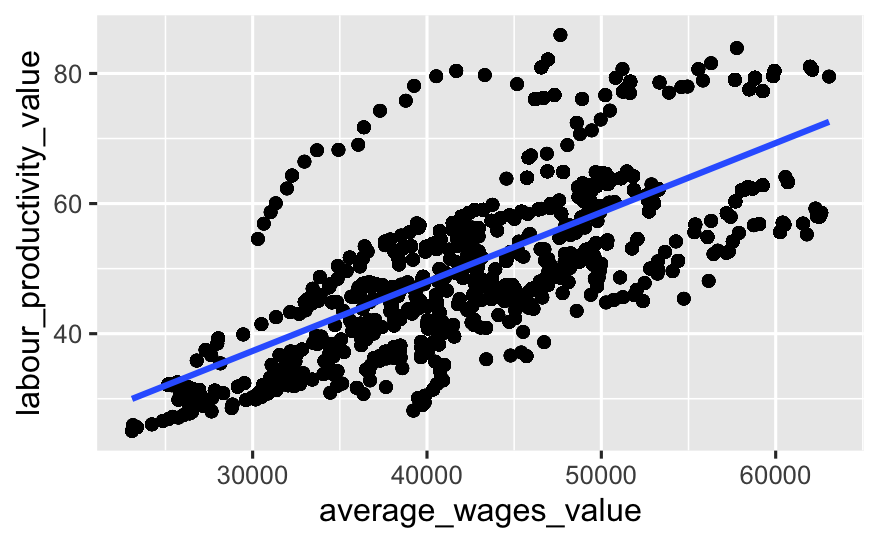

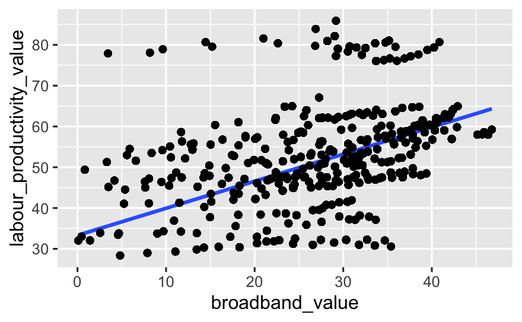

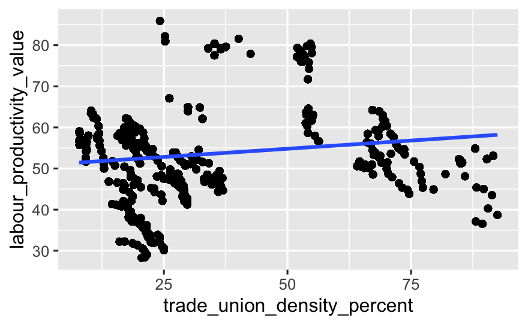

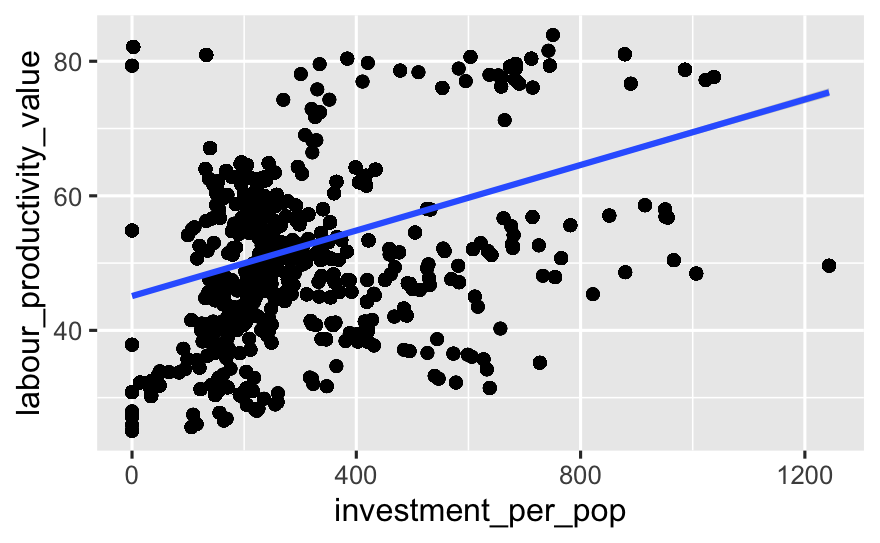

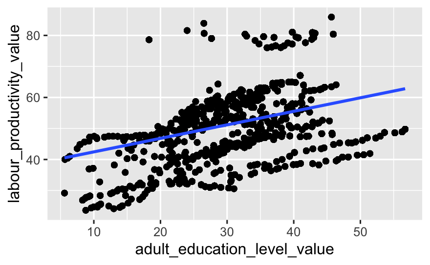

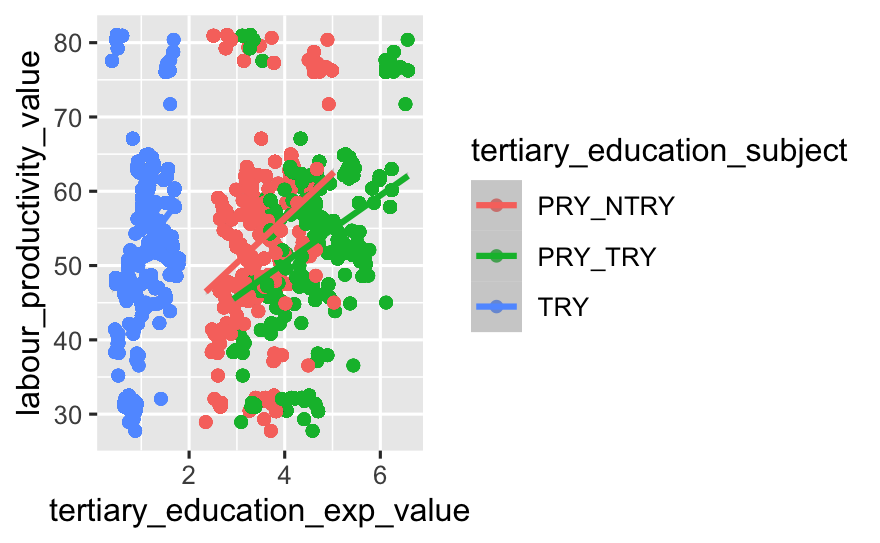

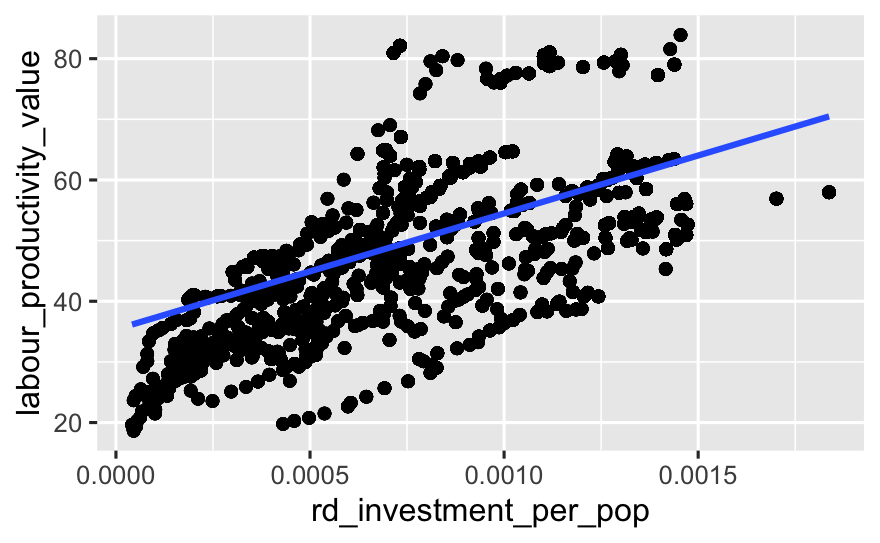

Based on these initial graphs the following data will be used as predictors for labour productivity: -average_wages_value -broadband_value -infrastructure investment per population -adult_education_level_value -research and development investment per population

subset our data for these variables

| location | time | labour_productivity_measure | labour_productivity_value | average_wages_value | broadband_value | r_d_research_value | adult_education_level_value | total_investment | population | rd_invest_per_pop | infra_invest_per_pop |
| --- | --- | --- | --- | --- | --- | --- | --- | --- | --- | --- | --- |
| BEL | 2008 | USD | 62.15517 | 48808.87 | 27.668 | 8368.98035 | 32.310043 | 1645865787 | 10709973 | 7.814194e-04 | 153.675998 |
| BEL | 2009 | USD | 61.71529 | 49226.93 | 29.028 | 8440.76608 | 33.397053 | 2102314281 | 10796493 | 7.818063e-04 | 194.721960 |
| BEL | 2010 | USD | 63.09741 | 48940.58 | 30.958 | 8958.22353 | 34.989502 | 2138467073 | 10895586 | 8.221883e-04 | 196.269120 |
| BEL | 2011 | USD | 62.80425 | 49382.39 | 32.234 | 9584.11979 | 34.612984 | 1970066303 | 11038264 | 8.682633e-04 | 178.476099 |
| BEL | 2012 | USD | 62.66814 | 49714.55 | 33.358 | 10132.59300 | 35.316551 | 2348431630 | 11106932 | 9.122765e-04 | 211.438373 |
| BEL | 2013 | USD | 63.07668 | 50362.66 | 34.417 | 10423.55107 | 35.535332 | 2244786096 | 11159407 | 9.340596e-04 | 201.156396 |
| FRA | 2008 | USD | 56.32827 | 39512.64 | 27.638 | 48667.68496 | 27.233906 | 18871901651 | 64374984 | 7.560031e-04 | 293.155827 |
| FRA | 2009 | USD | 55.75214 | 40732.42 | 30.562 | 50694.31406 | 28.588057 | 19324464990 | 64707040 | 7.834436e-04 | 298.645480 |
| FRA | 2010 | USD | 56.47384 | 41547.57 | 32.681 | 50908.16178 | 29.006897 | 19504363953 | 65027507 | 7.828712e-04 | 299.940208 |
| FRA | 2011 | USD | 57.03932 | 41472.27 | 34.822 | 52277.74031 | 29.767000 | 19306195274 | 65342780 | 8.000538e-04 | 295.460268 |

[output cut: 990 more lines]

Try multi-linear regression model

```r
summary(productivity_multi_lin_model)
```

```
Call:
lm(formula = labour_productivity_value ~ average_wages_value +
    broadband_value + adult_education_level_value + rd_invest_per_pop +
    infra_invest_per_pop, data = model_data)

Residuals:
     Min       1Q   Median       3Q      Max
-22.5065  -4.2010  -0.9247   3.8848  30.8698

Coefficients:
                              Estimate Std. Error t value Pr(>|t|)
(Intercept)                  6.602e+00  2.663e+00   2.479   0.0138 *
average_wages_value          1.003e-03  7.841e-05  12.795  < 2e-16 ***
broadband_value              2.725e-01  5.674e-02   4.803 2.60e-06 ***
adult_education_level_value -2.753e-01  6.376e-02  -4.317 2.22e-05 ***
rd_invest_per_pop            2.473e+03  1.650e+03   1.499   0.1351
infra_invest_per_pop         4.845e-03  2.581e-03   1.877   0.0616 .
---
Signif. codes:  0 ‘***’ 0.001 ‘**’ 0.01 ‘*’ 0.05 ‘.’ 0.1 ‘ ’ 1

Residual standard error: 7.527 on 270 degrees of freedom
  (791 observations deleted due to missingness)
Multiple R-squared:  0.6177,    Adjusted R-squared:  0.6106
F-statistic: 87.24 on 5 and 270 DF,  p-value: < 2.2e-16
```

800 data points removed due to missing values, therefore we are trying to predict productivity on only ~250 points, this might not be enough

| term | estimate | std_error | statistic | p_value |
| --- | --- | --- | --- | --- |
| (Intercept) | 6.601890e+00 | 2.662635e+00 | 2.479457 | 1.376889e-02 |
| average_wages_value | 1.003250e-03 | 7.841007e-05 | 12.794911 | 1.279506e-29 |
| broadband_value | 2.725305e-01 | 5.674464e-02 | 4.802753 | 2.597254e-06 |
| adult_education_level_value | -2.752581e-01 | 6.375855e-02 | -4.317195 | 2.220840e-05 |
| rd_invest_per_pop | 2.472697e+03 | 1.649914e+03 | 1.498682 | 1.351244e-01 |
| infra_invest_per_pop | 4.845006e-03 | 2.581166e-03 | 1.877061 | 6.158799e-02 |

r&d investment isn’t statistically significant

[figure not shown]

```r
par(mfrow = c(2, 2))
plot(productivity_multi_lin_model)
```

Diagnostic charts don’t look great for our model

Let’s run cross validation on the model:

```r
productivity_multi_lin_model_cv <- train(labour_productivity_value ~ average_wages_value + broadband_value + adult_education_level_value + rd_invest_per_pop,
               data = model_data_complete,
               trControl = cv_10_fold,
               method = 'lm')
```

[output not shown]

```r
mean(productivity_multi_lin_model_cv$resample$RMSE)
```

```
[1] 7.476536
```

```r
mean(productivity_multi_lin_model_cv$resample$Rsquared)
```

```
[1] 0.6304643
```

Let’s try international data on logistic regression